# Nvidia stock price forecast

```python
import pandas as pd
import numpy as np
from itertools import product
from collections import defaultdict

# Stationarity tests
from statsmodels.tsa.stattools import adfuller, kpss

# Autocorr test
from statsmodels.stats.diagnostic import acorr_ljungbox

# Autocorrelation analysis
from statsmodels.tsa.stattools import acf, pacf
from statsmodels.graphics.tsaplots import plot_acf, plot_pacf

#Metric evaluation
from utilsforecast.losses import rmse, mape, mae
from utilsforecast.evaluation import evaluate

# Visualizations
import matplotlib.pyplot as plt
import plotly.express as px
import seaborn as sns
from scipy.stats import norm
import scipy.stats as stats
```

```python
#Ridge regression
!pip install mlforecast==1.0.1

from mlforecast import MLForecast
from mlforecast.lag_transforms import ExpandingMean, RollingMean
from mlforecast.target_transforms import Differences

from sklearn.preprocessing import PolynomialFeatures
from sklearn.linear_model import Ridge
from sklearn.pipeline import Pipeline
from sklearn.preprocessing import StandardScaler
```

```python
#XGboost
!pip install xgboost==2.1.3

import xgboost as xgb
```

```python
#ARIMA

!pip install statsforecast==2.0.0

from statsforecast import StatsForecast
from statsforecast.models import AutoARIMA
from statsforecast.arima import arima_string
```

```python
#LSTM
!pip install neuralforecast==2.0.1

import logging

from neuralforecast import NeuralForecast
from neuralforecast.models import LSTM, NHITS, RNN

logging.getLogger('pytorch_lightning').setLevel(logging.ERROR)
```

```python
#Prophet
!pip install prophet==1.1.6

import prophet as fp
from prophet.diagnostics import performance_metrics, cross_validation
```

```python
import warnings
warnings.filterwarnings('ignore')
```

```python
#Create new file with logs every run for model versioning and model metrics logging

import logging, datetime, sys

dateTag = datetime.datetime.now().strftime("%d-%b-%Y_%H-%M-%S")
model_metrics_logger = logging.getLogger('nvidia_model_metrics')

model_metrics_logger.handlers.clear()
model_metrics_logger.addHandler(logging.FileHandler("nvidia_model_metrics_%s.log" % dateTag))
model_metrics_logger.addHandler(logging.StreamHandler(sys.stdout))
model_metrics_logger.setLevel(level=logging.INFO)
```

```python
random_state = 42
```

```python
def evaluate_cross_validation(df, metrics):
    """
    Calculate metric score for cross-validation
    """
    models = df.drop(columns=['unique_id', 'ds', 'cutoff', 'y']).columns.tolist()
    evals = []
    # Calculate loss for every unique_id and cutoff.
    for cutoff in df['cutoff'].unique():
        eval_ = evaluate(df[df['cutoff'] == cutoff], metrics=metrics, models=models)

        evals.append(eval_)
    evals = pd.concat(evals)
    evals = evals.groupby(['unique_id', 'metric']).mean(numeric_only=True) # Averages the error metrics for all cutoffs for every combination of model and unique_id
    return evals
```

```python
class GridSearch:
    """
    Class for making grid search of hyperparameters for models by using cross-validation.
    """
    def __init__(self, all_params, model_initializer, calculate_score):
        self.all_params = all_params
        self.calculate_score = calculate_score
        self.initialize_model = model_initializer
        self.results_df = None
        self.best_params = None
        self.best_score = None


    def search(self):
        """ Evaluate vie cross-validation score for each set of hyperparameters from grid and write them to result DataFrame.
        """
        params_product = self.__params_product()
        results_dict = dict()

        for item in enumerate(params_product):

            index = item[0]
            params = item[1]

            model = self.initialize_model(params)

            current_score = self.calculate_score(model)

            if self.best_score is None or current_score < self.best_score:
                self.best_score = current_score
                self.best_params = params


            print(f'Iteration: {index + 1} of {len(params_product)}\n\tParams: {params}\n\tScore: {current_score}')
            results_dict.setdefault('score', []).append(current_score)
            self.__add_to_results(results_dict, params)


        print(f'Best score: {self.best_score} \n\twith params {self.best_params}')

        self.results_df = pd.DataFrame(results_dict).sort_values(by='score')



    def display_results(self):
        """ Display result table with hyperparameters sorted by score.
        """
        display(self.results_df)


    def get_best_params(self):
        """ Return hyperparameters which showed higher score on cross-validation.
        """
        return self.best_params


    def __add_to_results(self, results, params):
        for k, v in params.items():
                result_params = results.setdefault(k, [])
                result_params.append(v)




    def __params_product(self):
        return [dict(zip(self.all_params.keys(), vcomb)) for vcomb in product(*self.all_params.values())]
```

```python
def my_mape(predictions, targets):
    """ Calculate MAPE score.
    """
    return np.mean(np.abs((predictions - targets) / predictions)) * 100
```

```python
def adf_test(timeseries):
    """ Calculate ADF test statistic.
    """
    print("Results of Dickey-Fuller Test:")
    dftest = adfuller(timeseries, autolag="AIC")
    dfoutput = pd.Series(
        dftest[0:4],
        index=[
            "Test Statistic",
            "p-value",
            "#Lags Used",
            "Number of Observations Used",
        ],
    )
    for key, value in dftest[4].items():
        dfoutput["Critical Value (%s)" % key] = value
    print(dfoutput)
```

```python
def plot_residuals(residuals):
    """ Plot for residuals analyzing:
        1. Residuals Plot.
        2. Histogram plus estimated density.
        3. Normal Q-Q Plot.
        4. Correlogram.
    """
    fig, axs = plt.subplots(nrows=2, ncols=2, figsize=(12, 10))

    # plot[1,1]
    residuals.plot(ax=axs[0,0])
    axs[0,0].set_title("Residuals")

    # plot
    sns.distplot(residuals, ax=axs[0,1], fit=norm) # add fit=norm to visualize norm distribution
    axs[0,1].set_title("Density plot - Residual")

    # plot
    stats.probplot(residuals, dist="norm", plot=axs[1,0])
    axs[1,0].set_title('Plot Q-Q')

    # plot
    plot_acf(residuals,  lags=35, ax=axs[1,1],color="fuchsia")
    axs[1,1].set_title("Autocorrelation")

    plt.show()
```

## Data preporation

We'll be analyzing closing stocks prices. Get data from [here](https://www.finam.ru/quote/batsnq/nvda/export/).

```python
stocks_full = pd.read_csv('NVDA_230122_250122.csv')
stocks_full.head()
```

|  | <TICKER> | <PER> | <DATE> | <TIME> | <OPEN> | <HIGH> | <LOW> | <CLOSE> | <VOL> |
| --- | --- | --- | --- | --- | --- | --- | --- | --- | --- |
| 0 | NVDA | D | 23/01/23 | 00:00:00 | 18.0690 | 19.245 | 17.819 | 19.192 | 15035650 |
| 1 | NVDA | D | 24/01/23 | 00:00:00 | 18.8370 | 19.484 | 18.825 | 19.265 | 9503480 |
| 2 | NVDA | D | 25/01/23 | 00:00:00 | 18.9125 | 19.365 | 18.581 | 19.332 | 8723800 |
| 3 | NVDA | D | 26/01/23 | 00:00:00 | 19.7240 | 20.162 | 19.278 | 19.799 | 8941270 |
| 4 | NVDA | D | 27/01/23 | 00:00:00 | 19.4620 | 20.627 | 19.424 | 20.356 | 10233070 |

Here's some simple preprocessing.

```python
stocks_full.index=pd.to_datetime(stocks_full['<DATE>']+stocks_full['<TIME>'],format="%d/%m/%y%H:%M:%S")
stocks_full.index.names = ['ds']

stocks_full.tail()
```

| ds | <TICKER> | <PER> | <DATE> | <TIME> | <OPEN> | <HIGH> | <LOW> | <CLOSE> | <VOL> |
| --- | --- | --- | --- | --- | --- | --- | --- | --- | --- |
| 2025-01-14 | NVDA | D | 14/01/25 | 00:00:00 | 136.07 | 136.34 | 130.06 | 131.83 | 5593743 |
| 2025-01-15 | NVDA | D | 15/01/25 | 00:00:00 | 133.66 | 136.45 | 131.30 | 136.29 | 5211418 |
| 2025-01-16 | NVDA | D | 16/01/25 | 00:00:00 | 138.69 | 138.72 | 133.50 | 133.56 | 4715181 |
| 2025-01-17 | NVDA | D | 17/01/25 | 00:00:00 | 136.62 | 138.50 | 135.48 | 137.74 | 4256849 |
| 2025-01-21 | NVDA | D | 21/01/25 | 00:00:00 | 139.26 | 141.83 | 137.09 | 140.83 | 4240929 |

```python
stocks = stocks_full.copy()

stocks.rename(columns={'<CLOSE>':'y'}, inplace=True)
stocks = stocks[['y']]

stocks = stocks.resample('D').mean().interpolate()
stocks['unique_id'] = 'stock_id'

stocks.reset_index(inplace=True)

stocks
```

|  | ds | y | unique_id |
| --- | --- | --- | --- |
| 0 | 2023-01-23 | 19.1920 | stock_id |
| 1 | 2023-01-24 | 19.2650 | stock_id |
| 2 | 2023-01-25 | 19.3320 | stock_id |
| 3 | 2023-01-26 | 19.7990 | stock_id |
| 4 | 2023-01-27 | 20.3560 | stock_id |
| ... | ... | ... | ... |
| 725 | 2025-01-17 | 137.7400 | stock_id |
| 726 | 2025-01-18 | 138.5125 | stock_id |
| 727 | 2025-01-19 | 139.2850 | stock_id |
| 728 | 2025-01-20 | 140.0575 | stock_id |
| 729 | 2025-01-21 | 140.8300 | stock_id |

730 rows × 3 columns

Let's plot our data.

```python
fig = px.line(stocks, x=stocks['ds'], y=stocks['y'],
              title="Closing stock prices (1 day)")

fig.update_layout(template='plotly_white', width=800, height=500)
fig.update_xaxes(title_text="date")
fig.update_yaxes(title_text="closing price")
fig.show()
```

[interactive chart not shown]

## Split dataset on train and test

Split your time series into train/test in proportion 80/20.

```python
train_size = int(len(stocks) * 0.8)
train, test = stocks[:train_size], stocks[train_size:]
```

Let's plot test and train closing stock prices

```python
fig = px.line(title="Closing stock prices (1 day)")
fig.add_scatter(x=train['ds'], y=train['y'], mode='lines', name='train', line=dict(color='blue'))
fig.add_scatter(x=test['ds'], y=test['y'], mode='lines', name='test', line=dict(color='green'))

fig.update_layout(template='plotly_white', width=1000, height=500)
fig.update_xaxes(title_text="date")
fig.update_yaxes(title_text="closing price")
fig.show()
```

[interactive chart not shown]

## Add continious exogenous variables

As a continuous exogenous variable, I added:

1. [Unemployment Rate](https://fred.stlouisfed.org/series/UNRATE)
2. [Federal Funds Effective Rate](https://fred.stlouisfed.org/series/FEDFUNDS)

```python
fed_funds = pd.read_csv('FEDFUNDS.csv')
unrate = pd.read_csv('UNRATE.csv')
```

```python
fed_funds.index=pd.to_datetime(fed_funds['observation_date'])
unrate.index=pd.to_datetime(unrate['observation_date'])
```

```python
fed_funds = fed_funds.resample('D').ffill()
unrate = unrate.resample('D').ffill()
```

```python
exogenous = fed_funds.merge(unrate, left_index=True, right_index=True)
exogenous.drop(columns=['observation_date_x', 'observation_date_y'], inplace=True)
exogenous.rename(columns={'FEDFUNDS':'fedfunds', 'UNRATE':'unrate'}, inplace=True)
exogenous.head()
```

| observation_date | fedfunds | unrate |
| --- | --- | --- |
| 2023-01-01 | 4.33 | 3.5 |
| 2023-01-02 | 4.33 | 3.5 |
| 2023-01-03 | 4.33 | 3.5 |
| 2023-01-04 | 4.33 | 3.5 |
| 2023-01-05 | 4.33 | 3.5 |

```python
train_with_exogenous = train.merge(exogenous, left_on='ds', right_index=True)
train_with_exogenous.head()
```

|  | ds | y | unique_id | fedfunds | unrate |
| --- | --- | --- | --- | --- | --- |
| 0 | 2023-01-23 | 19.192 | stock_id | 4.33 | 3.5 |
| 1 | 2023-01-24 | 19.265 | stock_id | 4.33 | 3.5 |
| 2 | 2023-01-25 | 19.332 | stock_id | 4.33 | 3.5 |
| 3 | 2023-01-26 | 19.799 | stock_id | 4.33 | 3.5 |
| 4 | 2023-01-27 | 20.356 | stock_id | 4.33 | 3.5 |

```python
future_exogenous = test.drop(columns=['y'])
future_exogenous['fedfunds'] = train_with_exogenous['fedfunds'].iloc[-1]
future_exogenous['unrate'] = train_with_exogenous['unrate'].iloc[-1]
future_exogenous.head()
```

|  | ds | unique_id | fedfunds | unrate |
| --- | --- | --- | --- | --- |
| 584 | 2024-08-29 | stock_id | 5.33 | 4.2 |
| 585 | 2024-08-30 | stock_id | 5.33 | 4.2 |
| 586 | 2024-08-31 | stock_id | 5.33 | 4.2 |
| 587 | 2024-09-01 | stock_id | 5.33 | 4.2 |
| 588 | 2024-09-02 | stock_id | 5.33 | 4.2 |

Plot Federal Funds Effective Rate against stock price.

```python
import plotly.graph_objects as go

# Create an empty fig
fig = go.Figure()

# Add y graph on the left
fig.add_trace(go.Scatter(
    x=train_with_exogenous['ds'],
    y=train_with_exogenous['y'],
    mode='lines',
    name='y',
    line=dict(color='blue'),
    yaxis='y1'  # Tie to y1
))

# Add x graph on the right
fig.add_trace(go.Scatter(
    x=train_with_exogenous['ds'],
    y=train_with_exogenous['fedfunds'],
    line_shape='hv',
    name='fedfunds',
    line=dict(color='red'),
    yaxis='y2'  # Tie to y1
))


fig.update_layout(
    title="Closing stock prices (daily)",
    template='plotly_white',
    width=1000,
    height=500,
    yaxis=dict(
        title='stock prices',
    ),
    yaxis2=dict(
        title='fedfunds',
        overlaying='y',  # Impose axes
        side='right'
    ),
    xaxis=dict(title='Date')
)

fig.show()
```

[interactive chart not shown]

Plot Unemployment Rate against stock price.

```python
import plotly.graph_objects as go

# Create an empty fig
fig = go.Figure()

# Add y graph on the left
fig.add_trace(go.Scatter(
    x=train_with_exogenous['ds'],
    y=train_with_exogenous['y'],
    mode='lines',
    name='y',
    line=dict(color='blue'),
    yaxis='y1'  # Tie to y1
))

# Add x graph on the right
fig.add_trace(go.Scatter(
    x=train_with_exogenous['ds'],
    y=train_with_exogenous['unrate'],
    line_shape='hv',
    name='unrate',
    line=dict(color='red'),
    yaxis='y2'  # Tie to y1
))


fig.update_layout(
    title="Closing stock prices (daily)",
    template='plotly_white',
    width=1000,
    height=500,
    yaxis=dict(
        title='stock prices',
    ),
    yaxis2=dict(
        title='unrate',
        overlaying='y',  # Impose axes
        side='right'
    ),
    xaxis=dict(title='Date')
)

fig.show()
```

[interactive chart not shown]

Plot correlation heatmap with exogenous variables

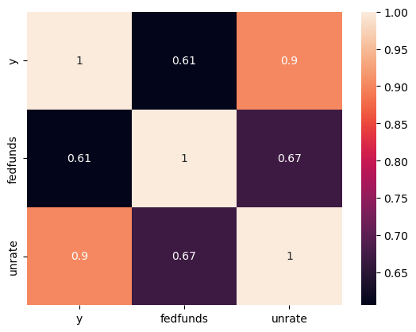

```python
sns.heatmap(train_with_exogenous[['y', 'fedfunds', 'unrate']].corr(), annot=True)
```

```python
train_with_exogenous.head()
```

|  | ds | y | unique_id | fedfunds | unrate |
| --- | --- | --- | --- | --- | --- |
| 0 | 2023-01-23 | 19.192 | stock_id | 4.33 | 3.5 |
| 1 | 2023-01-24 | 19.265 | stock_id | 4.33 | 3.5 |
| 2 | 2023-01-25 | 19.332 | stock_id | 4.33 | 3.5 |
| 3 | 2023-01-26 | 19.799 | stock_id | 4.33 | 3.5 |
| 4 | 2023-01-27 | 20.356 | stock_id | 4.33 | 3.5 |

## Stationarity analisys and differencing

Perform ADF test to check for stationarity

```python
adf_test(train['y'])
```

```
Results of Dickey-Fuller Test:
Test Statistic                   0.026515
p-value                          0.960671
#Lags Used                      19.000000
Number of Observations Used    564.000000
Critical Value (1%)             -3.441998
Critical Value (5%)             -2.866678
Critical Value (10%)            -2.569506
dtype: float64
```

**p-value > significance level (default: 0.05)** => we do NOT reject H(0) and our ts is not stationary (ADF).

Differencing is a common technique used to make a time series stationary by removing trends or seasonality. It is especially useful when the data shows patterns that change over time, such as increasing or decreasing trends.

**Formula** (1st order)

$ΔY_t = Y_t - Y_{t-1}$ or $y'_t = y_t - y_{t-1}$

```python
train_diff = train.copy()
train_diff['diff'] = train_diff['y'].diff()
train_diff.head()
```

|  | ds | y | unique_id | diff |
| --- | --- | --- | --- | --- |
| 0 | 2023-01-23 | 19.192 | stock_id | NaN |
| 1 | 2023-01-24 | 19.265 | stock_id | 0.073 |
| 2 | 2023-01-25 | 19.332 | stock_id | 0.067 |
| 3 | 2023-01-26 | 19.799 | stock_id | 0.467 |
| 4 | 2023-01-27 | 20.356 | stock_id | 0.557 |

Let's see if differencing of the 1st order made the time series stationary.

```python
fig = px.line(train_diff, x=train_diff.index, y=train_diff['diff'],
              title="Closing stock prices (daily) - diff(1))")

fig.update_layout(template='plotly_white', width=800, height=500)
fig.update_xaxes(title_text="date")
fig.update_yaxes(title_text="closing price")
fig.show()
```

[interactive chart not shown]

Differenced time series looks stationary. But let's test it using ADF test.

```python
adf_test(train_diff['diff'].dropna())
```

```
Results of Dickey-Fuller Test:
Test Statistic                  -5.169163
p-value                          0.000010
#Lags Used                      18.000000
Number of Observations Used    564.000000
Critical Value (1%)             -3.441998
Critical Value (5%)             -2.866678
Critical Value (10%)            -2.569506
dtype: float64
```

**p-value <= significance level (default: 0.05)** => we reject H(0) and our ts is stationary (ADF).

## Autocorelation analysys

Analyze autocorrelation of the time series with ACF, PACF.

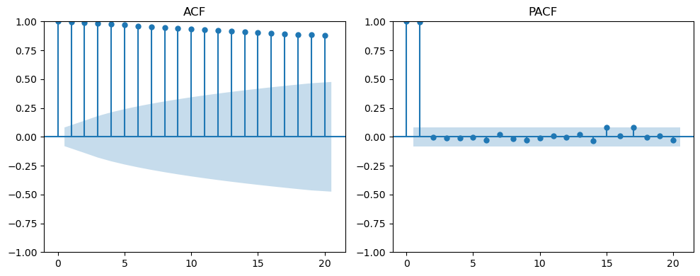

```python
# 2 graphs side by side
fig, ax = plt.subplots(1, 2, figsize=(10, 4))

# ACF
plot_acf(train['y'], ax=ax[0], lags=20)
ax[0].set_title('ACF')

# PACF
plot_pacf(train['y'], ax=ax[1], lags=20)
ax[1].set_title('PACF')


plt.tight_layout()
plt.show()
```

ACF decays slowly linearly (outside the confidence interval), it suggests autocorrelation.

Significant PACF values only at the first few lags suggest the series may follow an autoregressive process. PACF values become near-zero after the first few lags, it indicates that autocorrelation is primarily explained by the initial lags.

## Lineral Regression

Find best hyperparameters using grid serach and expanding window cross-validation

```python
def linear_regression_model_init(params):

    if params['standard_scaller']:
        linear_regression_model = Pipeline(steps=[
            ('scaller', StandardScaler()),
            ('poly', PolynomialFeatures(params['polynomial'])),
            ('estimator', Ridge(alpha=params['ridge_alpha'], random_state=random_state)),
        ])
    else:
        linear_regression_model = Pipeline(steps=[
            ('poly', PolynomialFeatures(params['polynomial'])),
            ('estimator', Ridge(alpha=params['ridge_alpha'], random_state=random_state)),
        ])


    return MLForecast(
        freq='D',
        models=[
            linear_regression_model,
        ],
        lags=params['lags'],
        target_transforms=[Differences([1])]
    )
```

```python
def linear_regression_cv_score(model):
    cv_results = model.cross_validation(
        df = train_with_exogenous,
        h = 200,
        step_size = 40,
        n_windows = 5,
        static_features=[]
    )

    cv_results = evaluate_cross_validation(cv_results, [mape])

    return cv_results.loc['stock_id', 'mape']['Ridge']
```

```python
grid_search_linear_regression = GridSearch(
    all_params={
        'lags':[[1], [1, 2], [1, 2, 3]],
        'polynomial': [1, 2],
        'standard_scaller': [True, False],
        'ridge_alpha': [0.01, 0.1, 1, 10, 100]
    },
    model_initializer=linear_regression_model_init,
    calculate_score=linear_regression_cv_score
)
```

```python
grid_search_linear_regression.search()
```

```
Iteration: 1 of 60
	Params: {'lags': [1], 'polynomial': 1, 'standard_scaller': True, 'ridge_alpha': 0.01}
	Score: 0.2669769730795129
Iteration: 2 of 60
	Params: {'lags': [1], 'polynomial': 1, 'standard_scaller': True, 'ridge_alpha': 0.1}
	Score: 0.2669524337872583
Iteration: 3 of 60
	Params: {'lags': [1], 'polynomial': 1, 'standard_scaller': True, 'ridge_alpha': 1}
	Score: 0.2667087667488829
Iteration: 4 of 60
	Params: {'lags': [1], 'polynomial': 1, 'standard_scaller': True, 'ridge_alpha': 10}
	Score: 0.26443871061255037
Iteration: 5 of 60
	Params: {'lags': [1], 'polynomial': 1, 'standard_scaller': True, 'ridge_alpha': 100}
	Score: 0.2504232429743728
Iteration: 6 of 60
	Params: {'lags': [1], 'polynomial': 1, 'standard_scaller': False, 'ridge_alpha': 0.01}
	Score: 0.26683484241307853
Iteration: 7 of 60
	Params: {'lags': [1], 'polynomial': 1, 'standard_scaller': False, 'ridge_alpha': 0.1}
	Score: 0.26558362564969373
Iteration: 8 of 60
	Params: {'lags': [1], 'polynomial': 1, 'standard_scaller': False, 'ridge_alpha': 1}
	Score: 0.2565360722172092
Iteration: 9 of 60
	Params: {'lags': [1], 'polynomial': 1, 'standard_scaller': False, 'ridge_alpha': 10}
	Score: 0.2335140940123681
Iteration: 10 of 60
	Params: {'lags': [1], 'polynomial': 1, 'standard_scaller': False, 'ridge_alpha': 100}
	Score: 0.214894265994725
Iteration: 11 of 60
	Params: {'lags': [1], 'polynomial': 2, 'standard_scaller': True, 'ridge_alpha': 0.01}
	Score: 0.38369049971642866
Iteration: 12 of 60
	Params: {'lags': [1], 'polynomial': 2, 'standard_scaller': True, 'ridge_alpha': 0.1}
	Score: 0.383666797733491
Iteration: 13 of 60
	Params: {'lags': [1], 'polynomial': 2, 'standard_scaller': True, 'ridge_alpha': 1}
	Score: 0.3834260917877931
Iteration: 14 of 60
```

[output cut: 127 more lines]

```
	Score: 0.2813615604531774
Iteration: 57 of 60
	Params: {'lags': [1, 2, 3], 'polynomial': 2, 'standard_scaller': False, 'ridge_alpha': 0.1}
	Score: 0.2725629980593681
Iteration: 58 of 60
	Params: {'lags': [1, 2, 3], 'polynomial': 2, 'standard_scaller': False, 'ridge_alpha': 1}
	Score: 0.2701303341997282
Iteration: 59 of 60
	Params: {'lags': [1, 2, 3], 'polynomial': 2, 'standard_scaller': False, 'ridge_alpha': 10}
	Score: 0.2694251320330795
Iteration: 60 of 60
	Params: {'lags': [1, 2, 3], 'polynomial': 2, 'standard_scaller': False, 'ridge_alpha': 100}
	Score: 0.2598231739787819
Best score: 0.2146981493675065
	with params {'lags': [1, 2], 'polynomial': 1, 'standard_scaller': False, 'ridge_alpha': 100}
```

```python
grid_search_linear_regression.display_results()
```

|  | score | lags | polynomial | standard_scaller | ridge_alpha |
| --- | --- | --- | --- | --- | --- |
| 29 | 0.214698 | [1, 2] | 1 | False | 100.00 |
| 9 | 0.214894 | [1] | 1 | False | 100.00 |
| 49 | 0.214911 | [1, 2, 3] | 1 | False | 100.00 |
| 48 | 0.232984 | [1, 2, 3] | 1 | False | 10.00 |
| 28 | 0.233200 | [1, 2] | 1 | False | 10.00 |
| 8 | 0.233514 | [1] | 1 | False | 10.00 |
| 24 | 0.250033 | [1, 2] | 1 | True | 100.00 |
| 44 | 0.250122 | [1, 2, 3] | 1 | True | 100.00 |
| 4 | 0.250423 | [1] | 1 | True | 100.00 |
| 19 | 0.255736 | [1] | 2 | False | 100.00 |
| 27 | 0.255925 | [1, 2] | 1 | False | 1.00 |
| 39 | 0.255930 | [1, 2] | 2 | False | 100.00 |
| 47 | 0.256209 | [1, 2, 3] | 1 | False | 1.00 |
| 7 | 0.256536 | [1] | 1 | False | 1.00 |
| 59 | 0.259823 | [1, 2, 3] | 2 | False | 100.00 |
| 23 | 0.263765 | [1, 2] | 1 | True | 10.00 |
| 43 | 0.264245 | [1, 2, 3] | 1 | True | 10.00 |
| 3 | 0.264439 | [1] | 1 | True | 10.00 |
| 26 | 0.264870 | [1, 2] | 1 | False | 0.10 |
| 46 | 0.265416 | [1, 2, 3] | 1 | False | 0.10 |
| 6 | 0.265584 | [1] | 1 | False | 0.10 |
| 22 | 0.265988 | [1, 2] | 1 | True | 1.00 |
| 25 | 0.266110 | [1, 2] | 1 | False | 0.01 |
| 38 | 0.266161 | [1, 2] | 2 | False | 10.00 |
| 21 | 0.266227 | [1, 2] | 1 | True | 0.10 |
| 20 | 0.266251 | [1, 2] | 1 | True | 0.01 |
| 18 | 0.266376 | [1] | 2 | False | 10.00 |
| 42 | 0.266563 | [1, 2, 3] | 1 | True | 1.00 |
| 45 | 0.266692 | [1, 2, 3] | 1 | False | 0.01 |
| 2 | 0.266709 | [1] | 1 | True | 1.00 |
| 41 | 0.266812 | [1, 2, 3] | 1 | True | 0.10 |
| 5 | 0.266835 | [1] | 1 | False | 0.01 |
| 40 | 0.266837 | [1, 2, 3] | 1 | True | 0.01 |
| 1 | 0.266952 | [1] | 1 | True | 0.10 |
| 0 | 0.266977 | [1] | 1 | True | 0.01 |
| 37 | 0.267477 | [1, 2] | 2 | False | 1.00 |
| 17 | 0.268164 | [1] | 2 | False | 1.00 |
| 58 | 0.269425 | [1, 2, 3] | 2 | False | 10.00 |
| 57 | 0.270130 | [1, 2, 3] | 2 | False | 1.00 |
| 36 | 0.270185 | [1, 2] | 2 | False | 0.10 |
| 16 | 0.271055 | [1] | 2 | False | 0.10 |
| 56 | 0.272563 | [1, 2, 3] | 2 | False | 0.10 |
| 35 | 0.278816 | [1, 2] | 2 | False | 0.01 |
| 15 | 0.280374 | [1] | 2 | False | 0.01 |
| 55 | 0.281362 | [1, 2, 3] | 2 | False | 0.01 |
| 54 | 0.337144 | [1, 2, 3] | 2 | True | 100.00 |
| 50 | 0.342346 | [1, 2, 3] | 2 | True | 0.01 |
| 51 | 0.342396 | [1, 2, 3] | 2 | True | 0.10 |
| 52 | 0.342881 | [1, 2, 3] | 2 | True | 1.00 |
| 53 | 0.346224 | [1, 2, 3] | 2 | True | 10.00 |
| 14 | 0.350712 | [1] | 2 | True | 100.00 |
| 34 | 0.351602 | [1, 2] | 2 | True | 100.00 |
| 13 | 0.380741 | [1] | 2 | True | 10.00 |
| 33 | 0.381354 | [1, 2] | 2 | True | 10.00 |
| 12 | 0.383426 | [1] | 2 | True | 1.00 |
| 11 | 0.383667 | [1] | 2 | True | 0.10 |
| 10 | 0.383690 | [1] | 2 | True | 0.01 |
| 32 | 0.383703 | [1, 2] | 2 | True | 1.00 |
| 31 | 0.383893 | [1, 2] | 2 | True | 0.10 |
| 30 | 0.383911 | [1, 2] | 2 | True | 0.01 |

Let's fit the best model

```python
linear_regression_model = linear_regression_model_init(grid_search_linear_regression.get_best_params())
```

```python
linear_regression_model.fit(train_with_exogenous, static_features=[], fitted=True)
```

```
MLForecast(models=[Ridge], freq=D, lag_features=['lag1', 'lag2'], date_features=[], num_threads=1)
```

Plot and analyze residuals of the model

Residuals of the model: $e_t = y_t - \hat{y_t}$

In the best case: residuals are not autocorrelated and have zero mean.

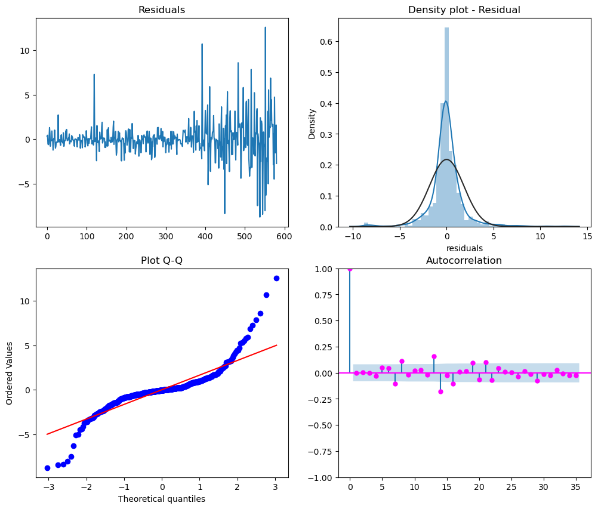

```python
fitted_predictions = linear_regression_model.forecast_fitted_values()
fitted_predictions['residuals'] = fitted_predictions['y'] - fitted_predictions['Ridge']
plot_residuals(fitted_predictions['residuals'])
```

**Residuals Plot** - top left

*What to look for?*

- Should look random with no obvious patterns:
  - The residuals should ideally behave like white noise—randomly distributed around zero, with no obvious patterns or trends.
  - Large deviations from zero may indicate the model isn’t capturing all patterns in the data.

*In our case*

Residuals have a zero mean but does not have constant variance

**Histogram plus estimated density** - top right

*What to look for?*

- Residuals should resemble a normal distribution (bell curve).
- Significant skewness or heavy tails suggests the model might not fully explain the data, or a transformation of the target variable may be needed.

*In our case*

The model might be overfitting certain parts of the data, leading to small residuals in some regions and large residuals in others

**Normal Q-Q Plot** - bottom left

*What to look for?*

- If the residuals are normally distributed, the points will lie approximately along a straight line (usually the 45-degree line).
- Deviations from this line indicate departures from normality (e.g., skewness, or outliers).

*In our case*

There are curves or deviations at the ends of the Q-Q plot (both the upper and lower tails), it suggests that our data may have fat tails (kurtosis) or more extreme values than a normal distribution would predict.

**Correlogram** - bottom right

The autocorrelation function (ACF) of the residuals, showing how correlated residuals are at different lags.

Out-of-sample forecasts

```python
predictions = linear_regression_model.predict(len(test), X_df=future_exogenous)

predictions.set_index(test.index, inplace=True)
```

```python
fig = px.line(title="Closing stock prices (daily)")
fig.add_scatter(x=train_with_exogenous['ds'], y=train_with_exogenous['y'], mode='lines', name='train', line=dict(color='blue'))
fig.add_scatter(x=test['ds'], y=test['y'], mode='lines', name='test', line=dict(color='green'))
fig.add_scatter(x=predictions['ds'], y=predictions['Ridge'], mode='lines', name='prediction', line=dict(color='red'))

fig.update_layout(template='plotly_white', width=1000, height=500)
fig.update_xaxes(title_text="date")
fig.update_yaxes(title_text="closing price")
fig.show()
```

[interactive chart not shown]

We can calculate quality metric by using MAPE

It has intuitive appeal and is suitable for this time series because:

- The values of $y_t$ are NOT close to zero
- The forecast NOT overestimates the actual metric

```python
lineral_regression_mape = my_mape(predictions['Ridge'], test['y'])
```

```python
model_metrics_logger.info(
    f'Model name: Ridge, MAPE score: {lineral_regression_mape}, random_state: {random_state}, hyperparameters: {grid_search_linear_regression.get_best_params()}'
)
```

```
Model name: Ridge, MAPE score: 6.639806891489361, random_state: 42, hyperparameters: {'lags': [1, 2], 'polynomial': 1, 'standard_scaller': False, 'ridge_alpha': 100}
```

Let's do the same for remaning models

# XGBoost

Find best hyperparameters using grid serach and expanding window cross-validation

```python
def xgboost_model_init(params):
    return MLForecast(
        freq='D',
        models=[
            xgb.XGBRegressor(
                objective='reg:squarederror',
                random_state=random_state,
                max_depth=params['max_depth'],
                reg_lambda=params['reg_lambda'],
                eta=params['eta']
            )
        ],
        lags=params['lags'],
        target_transforms=[Differences([1])]
    )
```

```python
def xgboost_cv_score(model):
    cv_results = model.cross_validation(
        df = train_with_exogenous,
        h = 200,
        step_size = 40,
        n_windows = 5,
        static_features=[]
    )

    cv_results = evaluate_cross_validation(cv_results, [mape])

    return cv_results.loc['stock_id', 'mape']['XGBRegressor']
```

```python
xgboost_grid_search = GridSearch(
    all_params={
        'lags':[[1, 2, 3, 4, 5]],
        'max_depth': [8, 10, 12],
        'reg_lambda': [0.01, 0.1, 1, 10],
        'eta': [0.3, 0.4, 0.5]
    },
    model_initializer=xgboost_model_init,
    calculate_score=xgboost_cv_score
)
```

```python
xgboost_grid_search.search()
```

```
Iteration: 1 of 36
	Params: {'lags': [1, 2, 3, 4, 5], 'max_depth': 8, 'reg_lambda': 0.01, 'eta': 0.3}
	Score: 0.24710968742109593
Iteration: 2 of 36
	Params: {'lags': [1, 2, 3, 4, 5], 'max_depth': 8, 'reg_lambda': 0.01, 'eta': 0.4}
	Score: 0.25866852380319244
Iteration: 3 of 36
	Params: {'lags': [1, 2, 3, 4, 5], 'max_depth': 8, 'reg_lambda': 0.01, 'eta': 0.5}
	Score: 0.2747023302697075
Iteration: 4 of 36
	Params: {'lags': [1, 2, 3, 4, 5], 'max_depth': 8, 'reg_lambda': 0.1, 'eta': 0.3}
	Score: 0.251255542531754
Iteration: 5 of 36
	Params: {'lags': [1, 2, 3, 4, 5], 'max_depth': 8, 'reg_lambda': 0.1, 'eta': 0.4}
	Score: 0.2466422687105192
Iteration: 6 of 36
	Params: {'lags': [1, 2, 3, 4, 5], 'max_depth': 8, 'reg_lambda': 0.1, 'eta': 0.5}
	Score: 0.2695433585009983
Iteration: 7 of 36
	Params: {'lags': [1, 2, 3, 4, 5], 'max_depth': 8, 'reg_lambda': 1, 'eta': 0.3}
	Score: 0.23869277460204125
Iteration: 8 of 36
	Params: {'lags': [1, 2, 3, 4, 5], 'max_depth': 8, 'reg_lambda': 1, 'eta': 0.4}
	Score: 0.2770514415974981
Iteration: 9 of 36
	Params: {'lags': [1, 2, 3, 4, 5], 'max_depth': 8, 'reg_lambda': 1, 'eta': 0.5}
	Score: 0.26658531805163854
Iteration: 10 of 36
	Params: {'lags': [1, 2, 3, 4, 5], 'max_depth': 8, 'reg_lambda': 10, 'eta': 0.3}
	Score: 0.26296241592646286
Iteration: 11 of 36
	Params: {'lags': [1, 2, 3, 4, 5], 'max_depth': 8, 'reg_lambda': 10, 'eta': 0.4}
	Score: 0.2745327058370768
Iteration: 12 of 36
	Params: {'lags': [1, 2, 3, 4, 5], 'max_depth': 8, 'reg_lambda': 10, 'eta': 0.5}
	Score: 0.3366078653247314
Iteration: 13 of 36
	Params: {'lags': [1, 2, 3, 4, 5], 'max_depth': 10, 'reg_lambda': 0.01, 'eta': 0.3}
	Score: 0.23085492628916363
Iteration: 14 of 36
```

[output cut: 55 more lines]

```
	Score: 0.2655119745385576
Iteration: 33 of 36
	Params: {'lags': [1, 2, 3, 4, 5], 'max_depth': 12, 'reg_lambda': 1, 'eta': 0.5}
	Score: 0.28895617272379415
Iteration: 34 of 36
	Params: {'lags': [1, 2, 3, 4, 5], 'max_depth': 12, 'reg_lambda': 10, 'eta': 0.3}
	Score: 0.31878789258844475
Iteration: 35 of 36
	Params: {'lags': [1, 2, 3, 4, 5], 'max_depth': 12, 'reg_lambda': 10, 'eta': 0.4}
	Score: 0.2578630743262931
Iteration: 36 of 36
	Params: {'lags': [1, 2, 3, 4, 5], 'max_depth': 12, 'reg_lambda': 10, 'eta': 0.5}
	Score: 0.24972185612236109
Best score: 0.22907282157330577
	with params {'lags': [1, 2, 3, 4, 5], 'max_depth': 10, 'reg_lambda': 0.01, 'eta': 0.4}
```

```python
xgboost_grid_search.display_results()
```

|  | score | lags | max_depth | reg_lambda | eta |
| --- | --- | --- | --- | --- | --- |
| 13 | 0.229073 | [1, 2, 3, 4, 5] | 10 | 0.01 | 0.4 |
| 12 | 0.230855 | [1, 2, 3, 4, 5] | 10 | 0.01 | 0.3 |
| 18 | 0.234838 | [1, 2, 3, 4, 5] | 10 | 1.00 | 0.3 |
| 6 | 0.238693 | [1, 2, 3, 4, 5] | 8 | 1.00 | 0.3 |
| 24 | 0.239887 | [1, 2, 3, 4, 5] | 12 | 0.01 | 0.3 |
| 4 | 0.246642 | [1, 2, 3, 4, 5] | 8 | 0.10 | 0.4 |
| 0 | 0.247110 | [1, 2, 3, 4, 5] | 8 | 0.01 | 0.3 |
| 35 | 0.249722 | [1, 2, 3, 4, 5] | 12 | 10.00 | 0.5 |
| 3 | 0.251256 | [1, 2, 3, 4, 5] | 8 | 0.10 | 0.3 |
| 23 | 0.257221 | [1, 2, 3, 4, 5] | 10 | 10.00 | 0.5 |
| 34 | 0.257863 | [1, 2, 3, 4, 5] | 12 | 10.00 | 0.4 |
| 1 | 0.258669 | [1, 2, 3, 4, 5] | 8 | 0.01 | 0.4 |
| 17 | 0.261270 | [1, 2, 3, 4, 5] | 10 | 0.10 | 0.5 |
| 27 | 0.261827 | [1, 2, 3, 4, 5] | 12 | 0.10 | 0.3 |
| 15 | 0.262392 | [1, 2, 3, 4, 5] | 10 | 0.10 | 0.3 |
| 9 | 0.262962 | [1, 2, 3, 4, 5] | 8 | 10.00 | 0.3 |
| 31 | 0.265512 | [1, 2, 3, 4, 5] | 12 | 1.00 | 0.4 |
| 8 | 0.266585 | [1, 2, 3, 4, 5] | 8 | 1.00 | 0.5 |
| 30 | 0.266677 | [1, 2, 3, 4, 5] | 12 | 1.00 | 0.3 |
| 14 | 0.267137 | [1, 2, 3, 4, 5] | 10 | 0.01 | 0.5 |
| 5 | 0.269543 | [1, 2, 3, 4, 5] | 8 | 0.10 | 0.5 |
| 25 | 0.269854 | [1, 2, 3, 4, 5] | 12 | 0.01 | 0.4 |
| 10 | 0.274533 | [1, 2, 3, 4, 5] | 8 | 10.00 | 0.4 |
| 2 | 0.274702 | [1, 2, 3, 4, 5] | 8 | 0.01 | 0.5 |
| 16 | 0.275123 | [1, 2, 3, 4, 5] | 10 | 0.10 | 0.4 |
| 19 | 0.276040 | [1, 2, 3, 4, 5] | 10 | 1.00 | 0.4 |
| 7 | 0.277051 | [1, 2, 3, 4, 5] | 8 | 1.00 | 0.4 |
| 21 | 0.286455 | [1, 2, 3, 4, 5] | 10 | 10.00 | 0.3 |
| 32 | 0.288956 | [1, 2, 3, 4, 5] | 12 | 1.00 | 0.5 |
| 20 | 0.295400 | [1, 2, 3, 4, 5] | 10 | 1.00 | 0.5 |
| 33 | 0.318788 | [1, 2, 3, 4, 5] | 12 | 10.00 | 0.3 |
| 22 | 0.323468 | [1, 2, 3, 4, 5] | 10 | 10.00 | 0.4 |
| 29 | 0.324654 | [1, 2, 3, 4, 5] | 12 | 0.10 | 0.5 |
| 26 | 0.333822 | [1, 2, 3, 4, 5] | 12 | 0.01 | 0.5 |
| 11 | 0.336608 | [1, 2, 3, 4, 5] | 8 | 10.00 | 0.5 |
| 28 | 0.345336 | [1, 2, 3, 4, 5] | 12 | 0.10 | 0.4 |

Let's fit the best model

```python
xgboost_model = xgboost_model_init(xgboost_grid_search.get_best_params())
xgboost_model.fit(train_with_exogenous, fitted=True, static_features=[])
```

```
MLForecast(models=[XGBRegressor], freq=D, lag_features=['lag1', 'lag2', 'lag3', 'lag4', 'lag5'], date_features=[], num_threads=1)
```

Plot and analyze residuals of the model

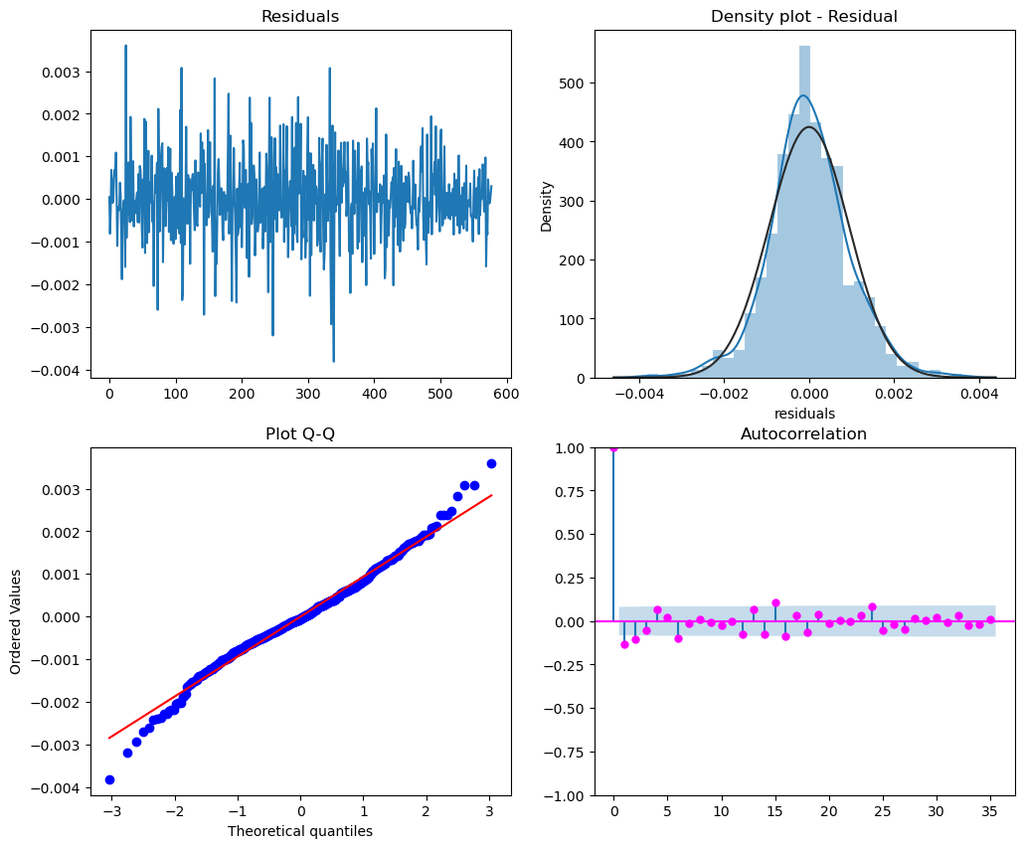

```python
fitted_xgboost_predictions = xgboost_model.forecast_fitted_values()
fitted_xgboost_predictions['residuals'] = fitted_xgboost_predictions['y'] - fitted_xgboost_predictions['XGBRegressor']
plot_residuals(fitted_xgboost_predictions['residuals'])
```

Out-of-sample forecasts

```python
xgboost_predictions = xgboost_model.predict(len(test), X_df=future_exogenous)

xgboost_predictions.set_index(test.index, inplace=True)
```

```python
fig = px.line(title="Closing stock prices (daily)")
fig.add_scatter(x=train_with_exogenous['ds'], y=train_with_exogenous['y'], mode='lines', name='train', line=dict(color='blue'))
fig.add_scatter(x=test['ds'], y=test['y'], mode='lines', name='test', line=dict(color='green'))
fig.add_scatter(x=xgboost_predictions['ds'], y=xgboost_predictions['XGBRegressor'], mode='lines', name='prediction', line=dict(color='red'))

fig.update_layout(template='plotly_white', width=1000, height=500)
fig.update_xaxes(title_text="date")
fig.update_yaxes(title_text="closing price")
fig.show()
```

[interactive chart not shown]

Calculate quality metric by using MAPE

```python
xgboost_mape = my_mape(xgboost_predictions['XGBRegressor'], test['y'])
```

```python
model_metrics_logger.info(
    f'Model name: XGBoost, MAPE score: {xgboost_mape}, random_state: {random_state}, hyperparameters: {xgboost_grid_search.get_best_params()}'
)
```

```
Model name: XGBoost, MAPE score: 5.832188711687431, random_state: 42, hyperparameters: {'lags': [1, 2, 3, 4, 5], 'max_depth': 10, 'reg_lambda': 0.01, 'eta': 0.4}
```

# LTSM

Find best hyperparameters using grid serach and expanding window cross-validation

```python
def ltsm_model_init(params):
    return NeuralForecast(
        freq='D',
        models=[
            LSTM(
                h=len(test), # Forecast horizon
                max_steps=100, # Number of steps to train
                scaler_type='standard', # Type of scaler to normalize data
                encoder_hidden_size=params['encoder_hidden_size'],#64, # Defines the size of the hidden state of the LSTM
                decoder_hidden_size=params['decoder_hidden_size'],#64,
                context_size=params['context_size'],#10,
                encoder_dropout=params['encoder_dropout'],#0,
                learning_rate=0.001,
                random_seed=random_state,
                futr_exog_list = [
                    "fedfunds",
                    "unrate"
                ]
            )
        ]
    )
```

```python
def ltsm_cv_score(model):
    cv_results = model.cross_validation(
        df = train_with_exogenous,
        step_size = 40,
        n_windows = 5,
        refit=True
    )

    cv_results = evaluate_cross_validation(cv_results, [mape])

    return cv_results.loc['stock_id', 'mape']['LSTM']
```

```python
ltsm_grid_search = GridSearch(
    all_params={
        'encoder_hidden_size': [32, 64, 128],
        'decoder_hidden_size': [32, 64, 128],
        'context_size': [5, 10, 20],
        'encoder_dropout': [0, 0.2, 0.4],
    },
    model_initializer=ltsm_model_init,
    calculate_score=ltsm_cv_score
)
```

```python
ltsm_grid_search.search()
```

```
Seed set to 42
```

[output not shown]

[output not shown]

[output not shown]

[output not shown]

[output not shown]

[output not shown]

[output not shown]

[output not shown]

[output not shown]

[output not shown]

[output not shown]

[output not shown]

[output not shown]

[output not shown]

[output not shown]

[output not shown]

[output not shown]

[output not shown]

[output not shown]

[output not shown]

```
Seed set to 42
```

```
Iteration: 1 of 81
	Params: {'encoder_hidden_size': 32, 'decoder_hidden_size': 32, 'context_size': 5, 'encoder_dropout': 0}
	Score: 0.3783891593529665
```

[output not shown]

[output not shown]

[output not shown]

[output not shown]

[output not shown]

[output not shown]

[output not shown]

[output not shown]

[output not shown]

[output not shown]

[output not shown]

[output not shown]

[output not shown]

[output not shown]

[output not shown]

[output not shown]

[output not shown]

[output not shown]

[output not shown]

[output not shown]

```
Seed set to 42
```

```
Iteration: 2 of 81
	Params: {'encoder_hidden_size': 32, 'decoder_hidden_size': 32, 'context_size': 5, 'encoder_dropout': 0.2}
	Score: 0.37634739438600945
```

[output not shown]

[output not shown]

[output not shown]

[output not shown]

[output not shown]

[output not shown]

[output not shown]

[output not shown]

[output not shown]

[output not shown]

[output not shown]

[output not shown]

[output not shown]

[output not shown]

[output not shown]

[output not shown]

[output not shown]

[output not shown]

[output not shown]

[output not shown]

```
Seed set to 42
```

```
Iteration: 3 of 81
	Params: {'encoder_hidden_size': 32, 'decoder_hidden_size': 32, 'context_size': 5, 'encoder_dropout': 0.4}
	Score: 0.3755775888311323
```

[output not shown]

[output not shown]

[output not shown]

[output not shown]

[output not shown]

[output not shown]

[output not shown]

[output not shown]

[output not shown]

[output not shown]

[output not shown]

[output not shown]

[output not shown]

[output not shown]

[output not shown]

[output not shown]

[output not shown]

[output not shown]

[output not shown]

[output not shown]

```
Seed set to 42
```

```
Iteration: 4 of 81
	Params: {'encoder_hidden_size': 32, 'decoder_hidden_size': 32, 'context_size': 10, 'encoder_dropout': 0}
	Score: 0.3648477756595448
```

[output not shown]

[output not shown]

[output not shown]

[output not shown]

[output not shown]

[output not shown]

[output not shown]

[output not shown]

[output not shown]

[output not shown]

[output not shown]

[output not shown]

[output not shown]

[output not shown]

[output not shown]

[output not shown]

[output not shown]

[output not shown]

[output not shown]

[output not shown]

```
Seed set to 42
```

```
Iteration: 5 of 81
	Params: {'encoder_hidden_size': 32, 'decoder_hidden_size': 32, 'context_size': 10, 'encoder_dropout': 0.2}
	Score: 0.3505734478179009
```

[output not shown]

[output not shown]

[output not shown]

[output not shown]

[output not shown]

[output not shown]

[output not shown]

[output not shown]

[output not shown]

[output not shown]

[output not shown]

[output not shown]

[output not shown]

[output not shown]

[output not shown]

[output not shown]

[output not shown]

[output not shown]

[output not shown]

[output not shown]

```
Seed set to 42
```

```
Iteration: 6 of 81
	Params: {'encoder_hidden_size': 32, 'decoder_hidden_size': 32, 'context_size': 10, 'encoder_dropout': 0.4}
	Score: 0.34822565083377083
```

[output not shown]

[output not shown]

[output not shown]

[output not shown]

[output not shown]

[output not shown]

[output not shown]

[output not shown]

[output not shown]

[output not shown]

[output not shown]

[output not shown]

[output not shown]

[output not shown]

[output not shown]

[output not shown]

[output not shown]

[output not shown]

[output not shown]

[output not shown]

```
Seed set to 42
```

```
Iteration: 7 of 81
	Params: {'encoder_hidden_size': 32, 'decoder_hidden_size': 32, 'context_size': 20, 'encoder_dropout': 0}
	Score: 0.36518396717715823
```

[output not shown]

[output not shown]

[output not shown]

[output not shown]

[output not shown]

[output not shown]

[output not shown]

[output not shown]

[output not shown]

[output not shown]

[output not shown]

[output not shown]

[output not shown]

[output not shown]

[output not shown]

[output not shown]

[output not shown]

[output not shown]

[output not shown]

[output not shown]

```
Seed set to 42
```

```
Iteration: 8 of 81
	Params: {'encoder_hidden_size': 32, 'decoder_hidden_size': 32, 'context_size': 20, 'encoder_dropout': 0.2}
	Score: 0.3593562309442529
```

[output not shown]

[output not shown]

[output not shown]

[output not shown]

[output not shown]

[output not shown]

[output not shown]

[output not shown]

[output not shown]

[output not shown]

[output not shown]

[output not shown]

[output not shown]

[output not shown]

[output not shown]

[output not shown]

[output not shown]

[output not shown]

[output not shown]

[output not shown]

```
Seed set to 42
```

```
Iteration: 9 of 81
	Params: {'encoder_hidden_size': 32, 'decoder_hidden_size': 32, 'context_size': 20, 'encoder_dropout': 0.4}
	Score: 0.3600092556190495
```

[output not shown]

[output not shown]

[output not shown]

[output not shown]

[output not shown]

[output not shown]

[output not shown]

[output not shown]

[output not shown]

[output not shown]

[output not shown]

[output not shown]

[output not shown]

[output not shown]

[output not shown]

[output not shown]

[output not shown]

[output not shown]

[output not shown]

[output not shown]

```
Seed set to 42
```

```
Iteration: 10 of 81
	Params: {'encoder_hidden_size': 32, 'decoder_hidden_size': 64, 'context_size': 5, 'encoder_dropout': 0}
	Score: 0.3736312435328405
```

[output not shown]

[output not shown]

[output not shown]

[output not shown]

[output not shown]

[output not shown]

[output not shown]

[output not shown]

[output not shown]

[output not shown]

[output not shown]

[output not shown]

[output not shown]

[output not shown]

[output not shown]

[output not shown]

[output not shown]

[output not shown]

[output not shown]

[output not shown]

```
Seed set to 42
```

```
Iteration: 11 of 81
	Params: {'encoder_hidden_size': 32, 'decoder_hidden_size': 64, 'context_size': 5, 'encoder_dropout': 0.2}
	Score: 0.3701796613831468
```

[output not shown]

[output not shown]

[output not shown]

[output not shown]

[output not shown]

[output not shown]

[output not shown]

[output not shown]

[output not shown]

[output not shown]

[output not shown]

[output not shown]

[output not shown]

[output not shown]

[output not shown]

[output not shown]

[output not shown]

[output not shown]

[output not shown]

[output not shown]

```
Seed set to 42
```

```
Iteration: 12 of 81
	Params: {'encoder_hidden_size': 32, 'decoder_hidden_size': 64, 'context_size': 5, 'encoder_dropout': 0.4}
	Score: 0.3712982190601159
```

[output not shown]

[output not shown]

[output not shown]

[output not shown]

[output not shown]

[output not shown]

[output not shown]

[output not shown]

[output not shown]

[output not shown]

[output not shown]

[output not shown]

[output not shown]

[output not shown]

[output not shown]

[output not shown]

[output not shown]

[output not shown]

[output not shown]

[output not shown]

```
Seed set to 42
```

```
Iteration: 13 of 81
	Params: {'encoder_hidden_size': 32, 'decoder_hidden_size': 64, 'context_size': 10, 'encoder_dropout': 0}
	Score: 0.36176864754484817
```

[output not shown]

[output not shown]

[output not shown]

[output not shown]

[output not shown]

[output not shown]

[output not shown]

[output not shown]

[output not shown]

[output not shown]

[output not shown]

[output not shown]

[output not shown]

[output not shown]

[output not shown]

[output not shown]

[output not shown]

[output not shown]

[output not shown]

[output not shown]

```
Seed set to 42
```

```
Iteration: 14 of 81
	Params: {'encoder_hidden_size': 32, 'decoder_hidden_size': 64, 'context_size': 10, 'encoder_dropout': 0.2}
	Score: 0.3587103952545808
```

[output not shown]

[output not shown]

[output not shown]

[output not shown]

[output not shown]

[output not shown]

[output not shown]

[output not shown]

[output not shown]

[output not shown]

[output not shown]

[output not shown]

[output not shown]

[output not shown]

[output not shown]

[output not shown]

[output not shown]

[output not shown]

[output not shown]

[output not shown]

```
Seed set to 42
```

```
Iteration: 15 of 81
	Params: {'encoder_hidden_size': 32, 'decoder_hidden_size': 64, 'context_size': 10, 'encoder_dropout': 0.4}
	Score: 0.35865300700438923
```

[output not shown]

[output not shown]

[output not shown]

[output not shown]

[output not shown]

[output not shown]

[output not shown]

[output not shown]

[output not shown]

[output not shown]

[output not shown]

[output not shown]

[output not shown]

[output not shown]

[output not shown]

[output not shown]

[output not shown]

[output not shown]

[output not shown]

[output not shown]

```
Seed set to 42
```

```
Iteration: 16 of 81
	Params: {'encoder_hidden_size': 32, 'decoder_hidden_size': 64, 'context_size': 20, 'encoder_dropout': 0}
	Score: 0.3744856774232271
```

[output not shown]

[output not shown]

[output not shown]

[output not shown]

[output not shown]

[output not shown]

[output not shown]

[output not shown]

[output not shown]

[output not shown]

[output not shown]

[output not shown]

[output not shown]

[output not shown]

[output not shown]

[output not shown]

[output not shown]

[output not shown]

[output not shown]

[output not shown]

```
Seed set to 42
```

```
Iteration: 17 of 81
	Params: {'encoder_hidden_size': 32, 'decoder_hidden_size': 64, 'context_size': 20, 'encoder_dropout': 0.2}
	Score: 0.3609122623969659
```

[output not shown]

[output not shown]

[output not shown]

[output not shown]

[output not shown]

[output not shown]

[output not shown]

[output not shown]

[output not shown]

[output not shown]

[output not shown]

[output not shown]

[output not shown]

[output not shown]

[output not shown]

[output not shown]

[output not shown]

[output not shown]

[output not shown]

[output not shown]

```
Seed set to 42
```

```
Iteration: 18 of 81
	Params: {'encoder_hidden_size': 32, 'decoder_hidden_size': 64, 'context_size': 20, 'encoder_dropout': 0.4}
	Score: 0.3582943737917793
```

[output not shown]

[output not shown]

[output not shown]

[output not shown]

[output not shown]

[output not shown]

[output not shown]

[output not shown]

[output not shown]

[output not shown]

[output not shown]

[output not shown]

[output not shown]

[output not shown]

[output not shown]

[output not shown]

[output not shown]

[output not shown]

[output not shown]

[output not shown]

```
Seed set to 42
```

```
Iteration: 19 of 81
	Params: {'encoder_hidden_size': 32, 'decoder_hidden_size': 128, 'context_size': 5, 'encoder_dropout': 0}
	Score: 0.40734552141654523
```

[output not shown]

[output not shown]

[output not shown]

[output not shown]

[output not shown]

[output not shown]

[output not shown]

[output not shown]

[output not shown]

[output not shown]

[output not shown]

[output not shown]

[output not shown]

[output not shown]

[output not shown]

[output not shown]

[output not shown]

[output not shown]

[output not shown]

[output not shown]

```
Seed set to 42
```

```
Iteration: 20 of 81
	Params: {'encoder_hidden_size': 32, 'decoder_hidden_size': 128, 'context_size': 5, 'encoder_dropout': 0.2}
	Score: 0.4079190179967099
```

[output not shown]

[output not shown]

[output not shown]

[output not shown]

[output not shown]

[output not shown]

[output not shown]

[output not shown]

[output not shown]

[output not shown]

[output not shown]

[output not shown]

[output not shown]

[output not shown]

[output not shown]

[output not shown]

[output not shown]

[output not shown]

[output not shown]

[output not shown]

```
Seed set to 42
```

```
Iteration: 21 of 81
	Params: {'encoder_hidden_size': 32, 'decoder_hidden_size': 128, 'context_size': 5, 'encoder_dropout': 0.4}
	Score: 0.40947360420770273
```

[output not shown]

[output not shown]

[output not shown]

[output not shown]

[output not shown]

[output not shown]

[output not shown]

[output not shown]

[output not shown]

[output not shown]

[output not shown]

[output not shown]

[output not shown]

[output not shown]

[output not shown]

[output not shown]

[output not shown]

[output not shown]

[output not shown]

[output not shown]

```
Seed set to 42
```

```
Iteration: 22 of 81
	Params: {'encoder_hidden_size': 32, 'decoder_hidden_size': 128, 'context_size': 10, 'encoder_dropout': 0}
	Score: 0.3704679968093623
```

[output not shown]

[output not shown]

[output not shown]

[output not shown]

[output not shown]

[output not shown]

[output not shown]

[output not shown]

[output not shown]

[output not shown]

[output not shown]

[output not shown]

[output not shown]

[output not shown]

[output not shown]

[output not shown]

[output not shown]

[output not shown]

[output not shown]

[output not shown]

```
Seed set to 42
```

```
Iteration: 23 of 81
	Params: {'encoder_hidden_size': 32, 'decoder_hidden_size': 128, 'context_size': 10, 'encoder_dropout': 0.2}
	Score: 0.35950506982291575
```

[output not shown]

[output not shown]

[output not shown]

[output not shown]

[output not shown]

[output not shown]

[output not shown]

[output not shown]

[output not shown]

[output not shown]

[output not shown]

[output not shown]

[output not shown]

[output not shown]

[output not shown]

[output not shown]

[output not shown]

[output not shown]

[output not shown]

[output not shown]

```
Seed set to 42
```

```
Iteration: 24 of 81
	Params: {'encoder_hidden_size': 32, 'decoder_hidden_size': 128, 'context_size': 10, 'encoder_dropout': 0.4}
	Score: 0.36305363124794576
```

[output not shown]

[output not shown]

[output not shown]

[output not shown]

[output not shown]

[output not shown]

[output not shown]

[output not shown]

[output not shown]

[output not shown]

[output not shown]

[output not shown]

[output not shown]

[output not shown]

[output not shown]

[output not shown]

[output not shown]

[output not shown]

[output not shown]

[output not shown]

```
Seed set to 42
```

```
Iteration: 25 of 81
	Params: {'encoder_hidden_size': 32, 'decoder_hidden_size': 128, 'context_size': 20, 'encoder_dropout': 0}
	Score: 0.3576398028625339
```

[output not shown]

[output not shown]

[output not shown]

[output not shown]

[output not shown]

[output not shown]

[output not shown]

[output not shown]

[output not shown]

[output not shown]

[output not shown]

[output not shown]

[output not shown]

[output not shown]

[output not shown]

[output not shown]

[output not shown]

[output not shown]

[output not shown]

[output not shown]

```
Seed set to 42
```

```
Iteration: 26 of 81
	Params: {'encoder_hidden_size': 32, 'decoder_hidden_size': 128, 'context_size': 20, 'encoder_dropout': 0.2}
	Score: 0.35923598310943494
```

[output not shown]

[output not shown]

[output not shown]

[output not shown]

[output not shown]

[output not shown]

[output not shown]

[output not shown]

[output not shown]

[output not shown]

[output not shown]

[output not shown]

[output not shown]

[output not shown]

[output not shown]

[output not shown]

[output not shown]

[output not shown]

[output not shown]

[output not shown]

```
Seed set to 42
```

```
Iteration: 27 of 81
	Params: {'encoder_hidden_size': 32, 'decoder_hidden_size': 128, 'context_size': 20, 'encoder_dropout': 0.4}
	Score: 0.35675452965409715
```

[output not shown]

[output not shown]

[output not shown]

[output not shown]

[output not shown]

[output not shown]

[output not shown]

[output not shown]

[output not shown]

[output not shown]

[output not shown]

[output not shown]

[output not shown]

[output not shown]

[output not shown]

[output not shown]

[output not shown]

[output not shown]

[output not shown]

[output not shown]

```
Seed set to 42
```

```
Iteration: 28 of 81
	Params: {'encoder_hidden_size': 64, 'decoder_hidden_size': 32, 'context_size': 5, 'encoder_dropout': 0}
	Score: 0.3583149558941475
```

[output not shown]

[output not shown]

[output not shown]

[output not shown]

[output not shown]

[output not shown]